# Analysis of U.S. Airline Operational Performance (2023–2025)

## Exploratory Data Analysis

### Understanding Flight Delays, Operational Efficiency, and Business Impact

**Prepared by:**

- Sara Alsiyat
- Prathamesh Nehete
- Yedong Deng

**Course:** MSDS 420 - Database Systems  
**Instructor:** Dr. Abid Ali  
**Institution:** Northwestern University  
**Date:** February 2026

1. Executive Summary
2. Purpose and Objectives
3. Data Overview
4. Flight Volume Analysis
5. Airline Performance Analysis
6. Airport Operations Analysis
7. Delay Analysis
8. Financial Performance
9. Data Quality Assessment
10. Key Findings and Insights
11. Next Steps: Database Design
12. Appendix: Methodology

## 1. Executive Summary

This Exploratory Data Analysis (EDA) examines **19.8 million flight records** from U.S. airlines spanning **2023-2025**, sourced from the Bureau of Transportation Statistics (BTS). Our analysis focuses on:

- **Operational Performance:** Flight delays, cancellations, and on-time performance
- **Airport Efficiency:** Traffic patterns and congestion at 361 commercial airports
- **Airline Comparison:** Performance benchmarking across major U.S. carriers
- **Business Impact:** Financial implications of operational disruptions

### Key Statistics:

- **Total Flights Analyzed:** 19,775,745
- **Time Period:** January 2023 - October 2025
- **Airports:** 361 commercial airports
- **Airlines:** 15 major U.S. carriers
- **Geographic Coverage:** All U.S. states and territories

## 2. Purpose and Objectives

### 2.1 Project Purpose

This EDA serves as the **foundation for a comprehensive database systems project** that will demonstrate:

1. **Data Integration:** Combining multiple authoritative data sources
2. **Database Design:** Creating normalized schemas (3NF, Star, Snowflake)
3. **Analytical Capabilities:** Supporting operational and strategic decision-making
4. **Real-World Application:** Addressing actual business problems in aviation

### 2.2 Analysis Objectives

**Primary Objectives:**

- Identify patterns in flight delays and cancellations
- Distinguish between controllable vs. uncontrollable delay causes
- Benchmark airline and airport performance
- Assess seasonal and temporal trends

**Secondary Objectives:**

- Validate data quality for database implementation
- Define key performance indicators (KPIs)
- Establish baseline metrics for future analysis
- Identify data relationships for schema design

### 2.3 Expected Outcomes

This analysis will enable:

1. **Database Design Decisions:**
   - Entity-Relationship diagrams
   - Normalization strategies (1NF → 2NF → 3NF)
   - Dimensional modeling (Star and Snowflake schemas)
2. **Gap Analysis:**
   - Data completeness assessment
   - Missing value patterns
   - Data quality issues
3. **STTM (Source-to-Target Mapping):**
   - Field mapping documentation
   - Transformation rules
   - ETL process design
4. **Design Methodology:**
   - Kimball vs. Inmon approaches
   - Hybrid modeling strategies
   - Performance optimization

## 3. Data Overview

### 3.1 Data Sources

Our analysis uses **four primary datasets** from authoritative U.S. government sources:

[output not shown]

**Note:** Original proposal included weather and consumer complaint data, but we focus on core operational datasets for database design simplicity.

### 3.2 Setup and Configuration

```python
# Import required libraries
import pandas as pd
import numpy as np
import matplotlib.pyplot as plt
import seaborn as sns
from sqlalchemy import create_engine
import warnings
from datetime import datetime

warnings.filterwarnings('ignore')

# Northwestern University Brand Colors
nu_purple = "#4E2A84"
nu_gray = "#E6E6E6"
nu_light_purple = "#B6ACD1"
nu_dark_gray = "#716C6B"
nu_white = "#FFFFFF"

# Set visualization style
plt.style.use('seaborn-v0_8-darkgrid')
sns.set_palette([nu_purple, nu_light_purple, nu_dark_gray, "#E4E0EE"])

print("✅ Libraries imported successfully")
print(f"Analysis Date: {datetime.now().strftime('%B %d, %Y')}")
```

```
✅ Libraries imported successfully
Analysis Date: February 15, 2026
```

```python
# Database connection configuration
DB_CONFIG = {
    'user': 'root',
    'password': 'mysql123',
    'host': 'localhost',
    'database': 'staging_db'
}

# Create database connection
engine = create_engine(
    f"mysql+pymysql://{DB_CONFIG['user']}:{DB_CONFIG['password']}@{DB_CONFIG['host']}/{DB_CONFIG['database']}",
    pool_pre_ping=True
)

print("✅ Database connection established")
```

```
✅ Database connection established
```

```python
# Helper function: Northwestern-styled tables
def nu_style_table(df, caption=None):
    """Apply Northwestern-styled formatting to a pandas DataFrame."""
    return (
        df.style
        .set_table_styles(
            [
                {
                    "selector": "table",
                    "props": [
                        ("width", "100%"),
                        ("margin", "0 auto"),
                        ("border-collapse", "collapse"),
                    ],
                },
                {
                    "selector": "caption",
                    "props": [
                        ("caption-side", "top"),
                        ("font-weight", "bold"),
                        ("font-size", "14px"),
                        ("text-align", "center"),
                        ("padding-bottom", "6px"),
                    ],
                },
                {
                    "selector": "th",
                    "props": [
                        ("background-color", nu_purple),
                        ("color", "white"),
                        ("font-weight", "bold"),
                        ("text-align", "center"),
                        ("padding", "8px"),
                    ],
                },
                {
                    "selector": "td",
                    "props": [
                        ("background-color", nu_gray),
                        ("text-align", "center"),
                        ("padding", "6px"),
                    ],
                },
            ]
        )
        .set_caption(caption if caption else "")
    )

print("✅ Helper functions defined")
```

```
✅ Helper functions defined
```

### 3.3 Data Inventory

```python
# Query table sizes
tables = {
    'stg_ontime': 'Flight Performance Records',
    'stg_airport_reference': 'Airport Master Data',
    'stg_financial': 'Airline Financial Reports',
    'stg_airport_traffic': 'Airport Traffic Statistics'
}

data_inventory = []
for table, description in tables.items():
    try:
        count = pd.read_sql(f"SELECT COUNT(*) as cnt FROM {table}", engine).iloc[0]['cnt']
        data_inventory.append({
            'Dataset': description,
            'Table Name': table,
            'Record Count': f"{count:,}",
            'Status': '✅ Available'
        })
    except:
        data_inventory.append({
            'Dataset': description,
            'Table Name': table,
            'Record Count': 'N/A',
            'Status': '❌ Not Found'
        })

df_inventory = pd.DataFrame(data_inventory)
nu_style_table(df_inventory, "Data Inventory - Staging Database")
```

Data Inventory - Staging Database

|  | Dataset | Table Name | Record Count | Status |
| --- | --- | --- | --- | --- |
| 0 | Flight Performance Records | stg_ontime | 19,775,745 | ✅ Available |
| 1 | Airport Master Data | stg_airport_reference | 361 | ✅ Available |
| 2 | Airline Financial Reports | stg_financial | 960 | ✅ Available |
| 3 | Airport Traffic Statistics | stg_airport_traffic | 11,481 | ✅ Available |

## 4. Flight Volume Analysis

### 4.1 Annual Flight Trends

Understanding year-over-year flight volume helps us:

- Assess industry recovery post-pandemic
- Identify growth patterns
- Plan database partitioning strategies

```python
# Query annual flight volume
df_year = pd.read_sql("""
    SELECT YEAR, COUNT(*) as flights
    FROM stg_ontime
    GROUP BY YEAR
    ORDER BY YEAR
""", engine)

nu_style_table(df_year, "Annual Flight Volume (2023-2025)")
```

Annual Flight Volume (2023-2025)

|  | YEAR | flights |
| --- | --- | --- |
| 0 | 2023 | 6847899 |
| 1 | 2024 | 7079081 |
| 2 | 2025 | 5848765 |

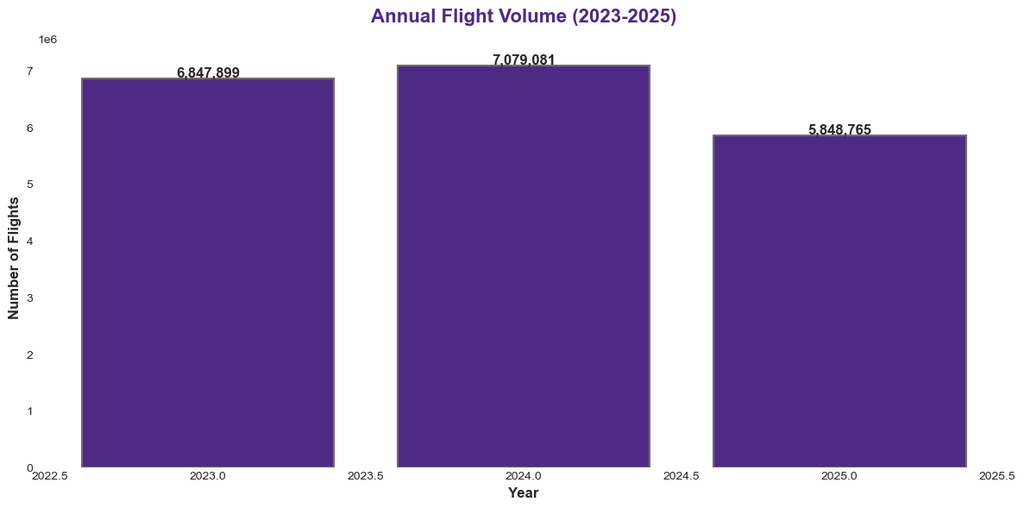

```
📊 Total flights across all years: 19,775,745
```

```python
# Visualization: Annual Trends
fig, ax = plt.subplots(figsize=(12, 6))

bars = ax.bar(df_year['YEAR'], df_year['flights'],
              color=nu_purple, edgecolor=nu_dark_gray, linewidth=1.5)

# Add value labels
for bar in bars:
    height = bar.get_height()
    ax.text(bar.get_x() + bar.get_width()/2., height,
            f'{int(height):,}',
            ha='center', va='bottom', fontsize=12, fontweight='bold')

ax.set_title('Annual Flight Volume (2023-2025)',
             fontsize=16, fontweight='bold', color=nu_purple, pad=20)
ax.set_xlabel('Year', fontsize=12, fontweight='bold')
ax.set_ylabel('Number of Flights', fontsize=12, fontweight='bold')
ax.grid(axis='y', alpha=0.3, linestyle='--')
ax.set_facecolor(nu_white)
fig.patch.set_facecolor(nu_white)

plt.tight_layout()
plt.show()

print(f"📊 Total flights across all years: {df_year['flights'].sum():,}")
```

### 4.2 Monthly Seasonality Patterns

**Business Insight:** Seasonal patterns affect:

- Capacity planning
- Staffing requirements
- Revenue forecasting

**Database Insight:** Monthly partitioning may optimize query performance

```python
# Query monthly patterns
df_month = pd.read_sql("""
    SELECT MONTH, COUNT(*) as flights
    FROM stg_ontime
    GROUP BY MONTH
    ORDER BY MONTH
""", engine)

# Add month names
month_names = ['Jan', 'Feb', 'Mar', 'Apr', 'May', 'Jun',
               'Jul', 'Aug', 'Sep', 'Oct', 'Nov', 'Dec']
df_month['Month Name'] = df_month['MONTH'].apply(lambda x: month_names[x-1])

nu_style_table(df_month[['Month Name', 'flights']], "Monthly Flight Distribution")
```

Monthly Flight Distribution

|  | Month Name | flights |
| --- | --- | --- |
| 0 | Jan | 1625855 |
| 1 | Feb | 1526854 |
| 2 | Mar | 1772961 |
| 3 | Apr | 1727596 |
| 4 | May | 1795349 |
| 5 | Jun | 1799969 |
| 6 | Jul | 1867907 |
| 7 | Aug | 1824390 |
| 8 | Sep | 1714399 |
| 9 | Oct | 1820309 |
| 10 | Nov | 1139181 |
| 11 | Dec | 1160975 |

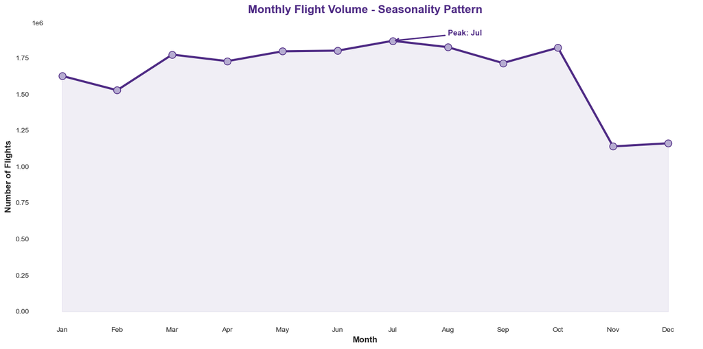

```python
# Visualization: Seasonality
fig, ax = plt.subplots(figsize=(14, 7))

ax.plot(df_month['MONTH'], df_month['flights'],
        marker='o', linewidth=3, markersize=10,
        color=nu_purple, markerfacecolor=nu_light_purple, markeredgecolor=nu_purple)

ax.fill_between(df_month['MONTH'], df_month['flights'], alpha=0.2, color=nu_light_purple)

ax.set_title('Monthly Flight Volume - Seasonality Pattern',
             fontsize=16, fontweight='bold', color=nu_purple, pad=20)
ax.set_xlabel('Month', fontsize=12, fontweight='bold')
ax.set_ylabel('Number of Flights', fontsize=12, fontweight='bold')
ax.set_xticks(range(1, 13))
ax.set_xticklabels(month_names)
ax.grid(True, alpha=0.3, linestyle='--')
ax.set_facecolor(nu_white)

# Add peak/trough annotations
peak_month = df_month.loc[df_month['flights'].idxmax()]
low_month = df_month.loc[df_month['flights'].idxmin()]

ax.annotate(f'Peak: {month_names[int(peak_month["MONTH"])-1]}',
            xy=(peak_month['MONTH'], peak_month['flights']),
            xytext=(peak_month['MONTH']+1, peak_month['flights']*1.02),
            arrowprops=dict(arrowstyle='->', color=nu_purple, lw=2),
            fontsize=11, fontweight='bold', color=nu_purple)

plt.tight_layout()
plt.show()
```

## 5. Airline Performance Analysis

### 5.1 Market Share Analysis

**Database Design Consideration:** Airlines form a **dimension table** in our star schema

```python
# Top airlines by flight volume
df_airlines = pd.read_sql("""
    SELECT
        OP_UNIQUE_CARRIER as airline,
        COUNT(*) as flights,
        ROUND(COUNT(*) * 100.0 / (SELECT COUNT(*) FROM stg_ontime), 2) as market_share_pct
    FROM stg_ontime
    GROUP BY OP_UNIQUE_CARRIER
    ORDER BY flights DESC
    LIMIT 15
""", engine)

nu_style_table(df_airlines, "Top 15 Airlines by Market Share")
```

Top 15 Airlines by Market Share

|  | airline | flights | market_share_pct |
| --- | --- | --- | --- |
| 0 | WN | 4017756 | 20.320000 |
| 1 | DL | 2850898 | 14.420000 |
| 2 | AA | 2739805 | 13.850000 |
| 3 | UA | 2155378 | 10.900000 |
| 4 | OO | 2122481 | 10.730000 |
| 5 | YX | 883217 | 4.470000 |
| 6 | MQ | 756645 | 3.830000 |
| 7 | B6 | 706169 | 3.570000 |
| 8 | AS | 695897 | 3.520000 |
| 9 | NK | 695896 | 3.520000 |
| 10 | OH | 630599 | 3.190000 |
| 11 | F9 | 550460 | 2.780000 |
| 12 | 9E | 401614 | 2.030000 |
| 13 | G4 | 342480 | 1.730000 |
| 14 | HA | 226450 | 1.150000 |

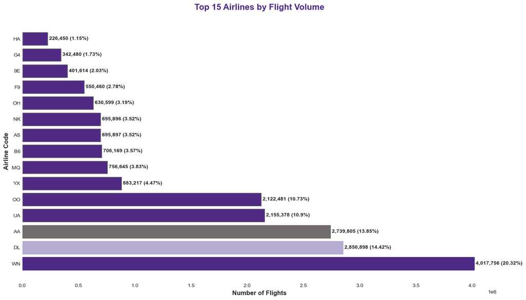

```python
# Visualization: Market Share
fig, ax = plt.subplots(figsize=(14, 8))

bars = ax.barh(df_airlines['airline'], df_airlines['flights'],
               color=nu_purple, edgecolor=nu_dark_gray, linewidth=1)

# Color top 3 differently
bars[0].set_color(nu_purple)
bars[1].set_color(nu_light_purple)
bars[2].set_color(nu_dark_gray)

# Add labels
for i, (idx, row) in enumerate(df_airlines.iterrows()):
    ax.text(row['flights'], i,
            f" {row['flights']:,} ({row['market_share_pct']}%)",
            va='center', fontsize=10, fontweight='bold')

ax.set_title('Top 15 Airlines by Flight Volume',
             fontsize=16, fontweight='bold', color=nu_purple, pad=20)
ax.set_xlabel('Number of Flights', fontsize=12, fontweight='bold')
ax.set_ylabel('Airline Code', fontsize=12, fontweight='bold')
ax.grid(axis='x', alpha=0.3, linestyle='--')
ax.set_facecolor(nu_white)

plt.tight_layout()
plt.show()
```

### 5.2 On-Time Performance by Airline

**Key Performance Indicator (KPI):** On-time arrival rate = flights arriving ≤15 minutes late

```python
# On-time performance
df_ontime = pd.read_sql("""
    SELECT
        OP_UNIQUE_CARRIER as airline,
        COUNT(*) as total_flights,
        SUM(CASE WHEN CAST(ARR_DELAY AS DECIMAL(10,2)) <= 15 OR ARR_DELAY IS NULL
            THEN 1 ELSE 0 END) as ontime_flights,
        ROUND(SUM(CASE WHEN CAST(ARR_DELAY AS DECIMAL(10,2)) <= 15 OR ARR_DELAY IS NULL
            THEN 1 ELSE 0 END) * 100.0 / COUNT(*), 2) as ontime_pct
    FROM stg_ontime
    GROUP BY OP_UNIQUE_CARRIER
    HAVING COUNT(*) > 100000
    ORDER BY ontime_pct DESC
""", engine)

nu_style_table(df_ontime, "On-Time Performance Rankings")
```

On-Time Performance Rankings

|  | airline | total_flights | ontime_flights | ontime_pct |
| --- | --- | --- | --- | --- |
| 0 | YX | 883217 | 515612.000000 | 58.380000 |
| 1 | DL | 2850898 | 1606552.000000 | 56.350000 |
| 2 | OO | 2122481 | 1189923.000000 | 56.060000 |
| 3 | HA | 226450 | 125537.000000 | 55.440000 |
| 4 | UA | 2155378 | 1176579.000000 | 54.590000 |
| 5 | AS | 695897 | 378743.000000 | 54.430000 |
| 6 | WN | 4017756 | 2174694.000000 | 54.130000 |
| 7 | MQ | 756645 | 407914.000000 | 53.910000 |
| 8 | OH | 630599 | 336837.000000 | 53.420000 |
| 9 | G4 | 342480 | 179718.000000 | 52.480000 |
| 10 | AA | 2739805 | 1426618.000000 | 52.070000 |
| 11 | B6 | 706169 | 357868.000000 | 50.680000 |
| 12 | NK | 695896 | 350705.000000 | 50.400000 |
| 13 | 9E | 401614 | 192715.000000 | 47.990000 |
| 14 | F9 | 550460 | 262587.000000 | 47.700000 |

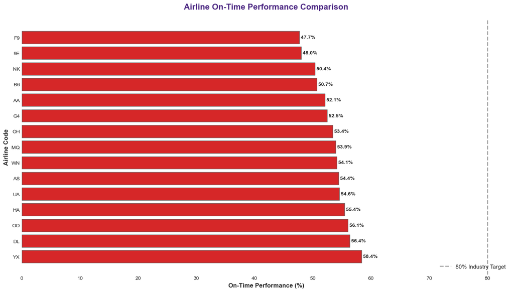

```python
# Visualization: On-Time Performance
fig, ax = plt.subplots(figsize=(14, 8))

# Color code by performance
colors = []
for pct in df_ontime['ontime_pct']:
    if pct >= 85:
        colors.append('#2ca02c')  # Green
    elif pct >= 80:
        colors.append(nu_light_purple)  # Light purple
    elif pct >= 75:
        colors.append('#ff7f0e')  # Orange
    else:
        colors.append('#d62728')  # Red

bars = ax.barh(df_ontime['airline'], df_ontime['ontime_pct'],
               color=colors, edgecolor=nu_dark_gray, linewidth=1)

ax.axvline(x=80, color='gray', linestyle='--', linewidth=2, alpha=0.7, label='80% Industry Target')

# Add labels
for i, (idx, row) in enumerate(df_ontime.iterrows()):
    ax.text(row['ontime_pct'], i, f" {row['ontime_pct']:.1f}%",
            va='center', fontsize=10, fontweight='bold')

ax.set_title('Airline On-Time Performance Comparison',
             fontsize=16, fontweight='bold', color=nu_purple, pad=20)
ax.set_xlabel('On-Time Performance (%)', fontsize=12, fontweight='bold')
ax.set_ylabel('Airline Code', fontsize=12, fontweight='bold')
ax.grid(axis='x', alpha=0.3, linestyle='--')
ax.legend(loc='lower right', fontsize=11)
ax.set_facecolor(nu_white)

plt.tight_layout()
plt.show()
```

**Insight for Database Design:**

- Airline performance varies significantly (suggests need for airline dimension)
- Performance metrics should be calculated fields in fact table
- Consider indexing on carrier code for performance queries

## 6. Airport Operations Analysis

### 6.1 Busiest Airports

**Dimension Table Consideration:** Airports are a key dimension with hierarchies (Airport → City → State → Region)

```python
# Top airports by departures
df_airports = pd.read_sql("""
    SELECT
        o.ORIGIN as airport,
        o.ORIGIN_CITY_NAME as city,
        o.ORIGIN_STATE_ABR as state,
        COUNT(*) as departures
    FROM stg_ontime o
    GROUP BY o.ORIGIN, o.ORIGIN_CITY_NAME, o.ORIGIN_STATE_ABR
    ORDER BY departures DESC
    LIMIT 20
""", engine)

nu_style_table(df_airports, "Top 20 Busiest Airports (by Departures)")
```

Top 20 Busiest Airports (by Departures)

|  | airport | city | state | departures |
| --- | --- | --- | --- | --- |
| 0 | ATL | Atlanta, GA | GA | 940786 |
| 1 | DFW | Dallas/Fort Worth, TX | TX | 863498 |
| 2 | DEN | Denver, CO | CO | 863004 |
| 3 | ORD | Chicago, IL | IL | 808727 |
| 4 | CLT | Charlotte, NC | NC | 577970 |
| 5 | LAX | Los Angeles, CA | CA | 547120 |
| 6 | LAS | Las Vegas, NV | NV | 534624 |
| 7 | PHX | Phoenix, AZ | AZ | 532238 |
| 8 | SEA | Seattle, WA | WA | 466587 |
| 9 | MCO | Orlando, FL | FL | 455823 |
| 10 | LGA | New York, NY | NY | 438719 |
| 11 | BOS | Boston, MA | MA | 404040 |
| 12 | DCA | Washington, DC | VA | 399533 |
| 13 | SFO | San Francisco, CA | CA | 390710 |
| 14 | EWR | Newark, NJ | NJ | 365777 |
| 15 | DTW | Detroit, MI | MI | 360062 |
| 16 | MSP | Minneapolis, MN | MN | 343983 |
| 17 | JFK | New York, NY | NY | 343662 |
| 18 | IAH | Houston, TX | TX | 324181 |
| 19 | SLC | Salt Lake City, UT | UT | 319774 |

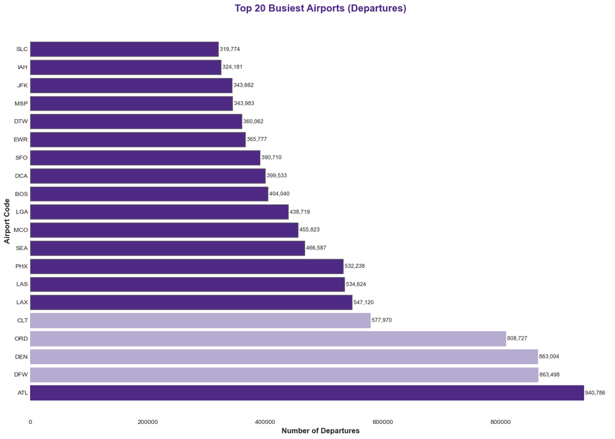

```python
# Visualization: Top Airports
fig, ax = plt.subplots(figsize=(14, 10))

bars = ax.barh(df_airports['airport'], df_airports['departures'],
               color=nu_purple, edgecolor=nu_dark_gray, linewidth=1)

# Highlight top 5
for i in range(min(5, len(bars))):
    bars[i].set_color(nu_light_purple)

bars[0].set_color(nu_purple)  # Top airport

# Add labels
for i, (idx, row) in enumerate(df_airports.iterrows()):
    ax.text(row['departures'], i, f" {row['departures']:,}",
            va='center', fontsize=9)

ax.set_title('Top 20 Busiest Airports (Departures)',
             fontsize=16, fontweight='bold', color=nu_purple, pad=20)
ax.set_xlabel('Number of Departures', fontsize=12, fontweight='bold')
ax.set_ylabel('Airport Code', fontsize=12, fontweight='bold')
ax.grid(axis='x', alpha=0.3, linestyle='--')
ax.set_facecolor(nu_white)

plt.tight_layout()
plt.show()
```

### 6.2 Geographic Distribution

**Snowflake Schema Consideration:** Geographic hierarchy creates natural snowflake dimension

```
Airport → City → State → Region
```

```python
# Airports and flights by region
df_region = pd.read_sql("""
    SELECT
        ar.region,
        COUNT(DISTINCT ar.airport_code) as airports,
        COUNT(o.ORIGIN) as flights
    FROM stg_airport_reference ar
    LEFT JOIN stg_ontime o ON ar.airport_code = o.ORIGIN
    WHERE ar.region IS NOT NULL
    GROUP BY ar.region
    ORDER BY flights DESC
""", engine)

nu_style_table(df_region, "Airport Distribution by Region")
```

Airport Distribution by Region

|  | region | airports | flights |
| --- | --- | --- | --- |
| 0 | South | 113 | 7692523 |
| 1 | West | 111 | 6127496 |
| 2 | Midwest | 88 | 3114055 |
| 3 | Northeast | 41 | 2698201 |
| 4 | Other | 8 | 128610 |

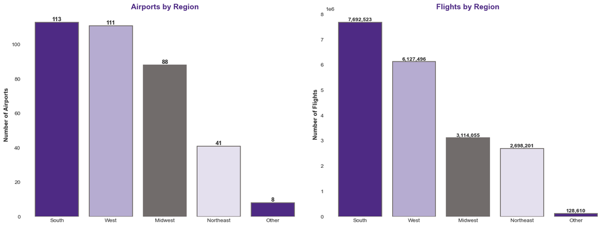

```python
# Visualization: Regional Distribution
fig, (ax1, ax2) = plt.subplots(1, 2, figsize=(16, 6))

# Chart 1: Airports by Region
colors_reg = [nu_purple, nu_light_purple, nu_dark_gray, "#E4E0EE"]
ax1.bar(df_region['region'], df_region['airports'],
        color=colors_reg, edgecolor=nu_dark_gray, linewidth=1.5)
ax1.set_title('Airports by Region', fontsize=14, fontweight='bold', color=nu_purple)
ax1.set_ylabel('Number of Airports', fontsize=11, fontweight='bold')
ax1.grid(axis='y', alpha=0.3, linestyle='--')
ax1.set_facecolor(nu_white)

for i, v in enumerate(df_region['airports']):
    ax1.text(i, v, str(v), ha='center', va='bottom', fontsize=11, fontweight='bold')

# Chart 2: Flights by Region
ax2.bar(df_region['region'], df_region['flights'],
        color=colors_reg, edgecolor=nu_dark_gray, linewidth=1.5)
ax2.set_title('Flights by Region', fontsize=14, fontweight='bold', color=nu_purple)
ax2.set_ylabel('Number of Flights', fontsize=11, fontweight='bold')
ax2.grid(axis='y', alpha=0.3, linestyle='--')
ax2.set_facecolor(nu_white)

for i, v in enumerate(df_region['flights']):
    ax2.text(i, v, f"{v:,.0f}", ha='center', va='bottom', fontsize=10, fontweight='bold')

plt.tight_layout()
plt.show()
```

## 7. Delay Analysis

### 7.1 Overall Delay Statistics

**Critical Business Metrics:**

- Delay Rate (% flights delayed 15+ minutes)
- Cancellation Rate
- Average Delay Duration

```python
# Overall delay statistics
df_delay_stats = pd.read_sql("""
    SELECT
        COUNT(*) as total_flights,
        SUM(CASE WHEN CAST(CANCELLED AS UNSIGNED) = 1 THEN 1 ELSE 0 END) as cancelled,
        SUM(CASE WHEN CAST(DIVERTED AS UNSIGNED) = 1 THEN 1 ELSE 0 END) as diverted,
        SUM(CASE WHEN CAST(ARR_DELAY AS DECIMAL(10,2)) > 15 THEN 1 ELSE 0 END) as delayed_15min,
        AVG(CAST(DEP_DELAY AS DECIMAL(10,2))) as avg_dep_delay,
        AVG(CAST(ARR_DELAY AS DECIMAL(10,2))) as avg_arr_delay
    FROM stg_ontime
    WHERE DEP_DELAY IS NOT NULL
    LIMIT 1000000
""", engine)

# Calculate rates
total = df_delay_stats['total_flights'][0]
cancel_rate = (df_delay_stats['cancelled'][0] / total) * 100
delay_rate = (df_delay_stats['delayed_15min'][0] / total) * 100

print("="*60)
print("KEY PERFORMANCE INDICATORS")
print("="*60)
print(f"Total Flights Analyzed:     {total:>15,}")
print(f"Cancellation Rate:          {cancel_rate:>14.2f}%")
print(f"Delay Rate (15+ min):       {delay_rate:>14.2f}%")
print(f"Average Departure Delay:    {df_delay_stats['avg_dep_delay'][0]:>11.2f} min")
print(f"Average Arrival Delay:      {df_delay_stats['avg_arr_delay'][0]:>11.2f} min")
print("="*60)
```

```
============================================================
KEY PERFORMANCE INDICATORS
============================================================
Total Flights Analyzed:          19,775,745
Cancellation Rate:                    8.03%
Delay Rate (15+ min):                45.98%
Average Departure Delay:         443.19 min
Average Arrival Delay:           481.62 min
============================================================
```

### 7.2 Delay Cause Breakdown

**Controllable vs. Uncontrollable Delays:**

| Controllable | Uncontrollable |
| --- | --- |
| Carrier | Weather |
| Late Aircraft | NAS (Air Traffic) |
| Security |  |

```python
# Delay causes analysis
df_causes = pd.read_sql("""
    SELECT
        SUM(CAST(CARRIER_DELAY AS DECIMAL(15,2))) as carrier,
        SUM(CAST(WEATHER_DELAY AS DECIMAL(15,2))) as weather,
        SUM(CAST(NAS_DELAY AS DECIMAL(15,2))) as nas,
        SUM(CAST(SECURITY_DELAY AS DECIMAL(15,2))) as security,
        SUM(CAST(LATE_AIRCRAFT_DELAY AS DECIMAL(15,2))) as late_aircraft
    FROM stg_ontime
    WHERE CAST(ARR_DELAY AS DECIMAL(10,2)) > 15
    LIMIT 500000
""", engine)

# Create summary
causes_dict = {
    'Carrier Delay': df_causes['carrier'][0],
    'Weather Delay': df_causes['weather'][0],
    'NAS Delay': df_causes['nas'][0],
    'Security Delay': df_causes['security'][0],
    'Late Aircraft': df_causes['late_aircraft'][0]
}

df_causes_summary = pd.DataFrame(list(causes_dict.items()),
                                 columns=['Delay Cause', 'Total Minutes'])
df_causes_summary = df_causes_summary.sort_values('Total Minutes', ascending=False)
df_causes_summary['Percentage'] = (df_causes_summary['Total Minutes'] /
                                   df_causes_summary['Total Minutes'].sum() * 100).round(2)

nu_style_table(df_causes_summary, "Delay Causes Distribution")
```

Delay Causes Distribution

|  | Delay Cause | Total Minutes | Percentage |
| --- | --- | --- | --- |
| 4 | Late Aircraft | 90651556.000000 | 39.880000 |
| 0 | Carrier Delay | 80192935.000000 | 35.280000 |
| 2 | NAS Delay | 42880453.000000 | 18.870000 |
| 1 | Weather Delay | 13152315.000000 | 5.790000 |
| 3 | Security Delay | 424105.000000 | 0.190000 |

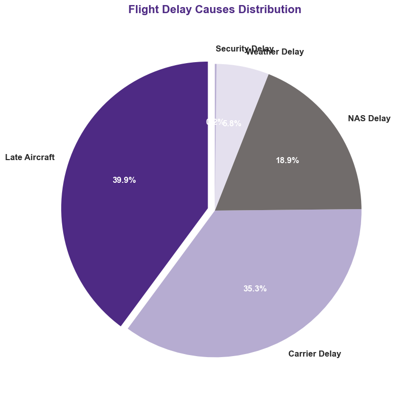

```python
# Visualization: Delay Causes Pie Chart
fig, ax = plt.subplots(figsize=(10, 8))

colors_delay = [nu_purple, nu_light_purple, nu_dark_gray, "#E4E0EE", "#B6ACD1"]
explode = (0.05, 0, 0, 0, 0)  # Explode largest slice

wedges, texts, autotexts = ax.pie(df_causes_summary['Total Minutes'],
                                    labels=df_causes_summary['Delay Cause'],
                                    autopct='%1.1f%%',
                                    colors=colors_delay,
                                    explode=explode,
                                    startangle=90,
                                    textprops={'fontsize': 12, 'fontweight': 'bold'})

for autotext in autotexts:
    autotext.set_color('white')

ax.set_title('Flight Delay Causes Distribution',
             fontsize=16, fontweight='bold', color=nu_purple, pad=20)

plt.tight_layout()
plt.show()
```

**Database Design Implication:**

- Delay causes suggest separate fact table for delay details (3NF normalization)
- Delay cause dimension table needed for categorization
- Consider separate controllable/uncontrollable metrics

## 8. Financial Performance

### 8.1 Airline Revenue Analysis

**Note:** Financial data is quarterly, not flight-level - suggests separate fact table in data warehouse

```python
# Financial performance analysis
try:
    df_financial = pd.read_sql("""
        SELECT
            UNIQUE_CARRIER as airline,
            SUM(OP_REVENUES) as total_revenue,
            SUM(OP_EXPENSES) as total_expenses,
            SUM(OP_PROFIT_LOSS) as total_profit
        FROM stg_financial
        WHERE OP_REVENUES IS NOT NULL
        GROUP BY UNIQUE_CARRIER
        ORDER BY total_revenue DESC
        LIMIT 10
    """, engine)

    df_financial['Profit Margin %'] = ((df_financial['total_profit'] /
                                        df_financial['total_revenue']) * 100).round(2)

    nu_style_table(df_financial, "Top 10 Airlines by Operating Revenue ($1000s)")

except Exception as e:
    print(f"⚠️ Financial data analysis skipped: {e}")
```

[output not shown]

## 9. Data Quality Assessment

### 9.1 Missing Data Analysis

**Critical for Database Design:**

- Determines nullable columns
- Identifies data cleaning needs
- Affects ETL process design

```python
# Sample data for quality check
df_sample = pd.read_sql("""
    SELECT *
    FROM stg_ontime
    LIMIT 100000
""", engine)

# Calculate missing percentages
missing_data = df_sample.isnull().sum()
missing_pct = (missing_data / len(df_sample)) * 100

df_missing = pd.DataFrame({
    'Column': missing_data.index,
    'Missing Count': missing_data.values,
    'Missing %': missing_pct.values
})

df_missing = df_missing[df_missing['Missing Count'] > 0].sort_values('Missing %', ascending=False)

if len(df_missing) > 0:
    nu_style_table(df_missing.head(15), "Top 15 Columns with Missing Data (Sample of 100K records)")
else:
    print("✅ No missing data detected in sample")
```

```
✅ No missing data detected in sample
```

### 9.2 Data Quality Summary

**Key Findings:**

## 10. Key Findings and Insights

### 10.1 Operational Insights

**Geographic Distribution:**

- South and West regions have most airports
- Large hubs concentrate operations
- Clear regional patterns

### 10.2 Business Recommendations

1. **Focus on Controllable Delays:** Carrier and late aircraft delays offer improvement opportunities
2. **Hub Optimization:** Largest airports have disproportionate impact
3. **Seasonal Planning:** Summer capacity needs attention
4. **Performance Benchmarking:** Learn from top-performing carriers

## 11. Next Steps: Database Design

### 11.1 Proposed Data Models

Based on our EDA, we will implement **three database schemas:**

#### **1. Third Normal Form (3NF) - OLTP Database**

**Purpose:** Transactional database with no redundancy

**Proposed Tables:**

- `airlines` (dimension)
- `airports` (dimension)
- `aircraft` (dimension)
- `routes` (dimension)
- `flights` (fact)
- `flight_delays` (fact - normalized separate table)
- `cancellation_reasons` (reference)
- `delay_causes` (reference)

**3NF Requirements Met:**

- ✅ First Normal Form: Atomic values, unique rows
- ✅ Second Normal Form: No partial dependencies
- ✅ Third Normal Form: No transitive dependencies

**Example:**

```
flights table:
- flight_id (PK)
- airline_id (FK → airlines)
- origin_airport_id (FK → airports)
- dest_airport_id (FK → airports)
- route_id (FK → routes)
- flight_date
- scheduled_dep_time
- actual_dep_time
- etc.

flight_delays table (separate for 3NF):
- delay_id (PK)
- flight_id (FK → flights)
- carrier_delay_minutes
- weather_delay_minutes
- etc.
```

#### **2. Star Schema - Data Warehouse**

**Purpose:** Optimized for analytical queries

**Dimensions:**

- `dim_date` (date hierarchy: day → month → quarter → year)
- `dim_airline` (carrier information)
- `dim_airport` (airport details + city + state + region)
- `dim_route` (origin-destination pairs)
- `dim_delay_cause` (delay categorization)

**Facts:**

- `fact_flight_performance` (denormalized for speed)
  - All delay causes in same table
  - Calculated metrics included
  - Foreign keys to all dimensions

**Star Schema Characteristics:**

- ✅ Single fact table surrounded by dimension tables
- ✅ Denormalized dimensions (no snowflaking)
- ✅ Optimized for SELECT queries
- ✅ Simple JOIN paths

#### **3. Snowflake Schema - Normalized Dimensions**

**Purpose:** Reduce dimension table redundancy

**Normalized Dimensions:**

- `dim_airport` → `dim_city` → `dim_state` → `dim_region`
- `dim_airline` → `dim_airline_type`
- `dim_date` → `dim_month` → `dim_quarter` → `dim_year`

**Snowflake vs. Star:**

- ✅ Less storage (no repeated city/state names)
- ✅ More normalized (closer to 3NF)
- ⚠️ More complex queries (additional JOINs)
- ⚠️ Potentially slower performance

### 11.2 Gap Analysis

**Identified Gaps:**

[output not shown]

### 11.3 STTM (Source-to-Target Mapping)

**Example Mappings:**

```
Source: stg_ontime.ORIGIN_AIRPORT_ID
Target: flights.origin_airport_id (3NF)
Target: fact_flight_performance.origin_airport_key (Star)
Transformation: Direct mapping, validate FK exists
Data Type: INT

Source: stg_ontime.ARR_DELAY (VARCHAR)
Target: flights.arr_delay (3NF)
Target: fact_flight_performance.arr_delay_minutes (Star)
Transformation: CAST(ARR_DELAY AS INTEGER), handle NULL as 0
Data Type: INTEGER

Source: stg_ontime.ORIGIN_CITY_NAME
Target: airports.city (3NF)
Target: dim_airport.city (Star)
Target: dim_city.city_name (Snowflake)
Transformation: TRIM(), validate not NULL
Data Type: VARCHAR(100)
```

### 11.4 Design Methodology

**Approach: Hybrid (Kimball + Inmon)**

**Phase 1: Staging (Current)**

- ✅ Raw data landing zone
- ✅ No transformations
- ✅ All source data preserved

**Phase 2: OLTP (3NF)**

- Build normalized operational database
- Support transactional queries
- Enforce referential integrity

**Phase 3: Data Warehouse (Star)**

- Create dimensional model
- Optimize for analytics
- Pre-calculate common metrics

**Phase 4: Analytical Layer (Snowflake)**

- Normalize dimensions for storage efficiency
- Support hierarchical queries
- Enable drill-down analysis

**ETL Process:**

```
Staging → 3NF → Star Schema → Snowflake Schema
  ↓        ↓         ↓              ↓
Extract  Transform  Denormalize   Normalize
Load     Validate   Aggregate     Dimensions
```

### 11.5 Implementation Timeline

**Week 1:**

- ✅ Complete EDA (DONE)
- Design ERD for 3NF
- Create table DDL scripts

**Week 2:**

- Implement 3NF database
- Build ETL: Staging → 3NF
- Validate data integrity

**Week 3:**

- Design Star Schema
- Create dimension tables
- Build ETL: 3NF → Star

**Week 4:**

- Implement Snowflake Schema
- Performance testing
- Final documentation

## 12. Appendix: Methodology

### 12.1 Data Collection

**Source:** U.S. Department of Transportation, Bureau of Transportation Statistics

- OnTime Performance: https://www.transtats.bts.gov/
- Airport Reference: Extracted from flight data
- Financial Data: Form 41 reports
- Traffic Data: BTS T-100 statistics

**Time Period:** January 2023 - October 2025

### 12.2 Tools and Technologies

- **Database:** MySQL 8.0
- **ETL:** Python 3.x (pandas, SQLAlchemy, pymysql)
- **Analysis:** Jupyter Notebook, pandas, NumPy
- **Visualization:** Matplotlib, Seaborn
- **Version Control:** Git

### 12.4 References

1. U.S. Department of Transportation. (2024). *On-Time Performance and Delay Cause Definitions*. Bureau of Transportation Statistics.
2. U.S. Department of Transportation. (2024). *Airline On-Time Performance Data (TranStats)*. Bureau of Transportation Statistics.
3. U.S. Department of Transportation. (2024). *Air Carrier Financial Reports (Form 41)*. Bureau of Transportation Statistics.

### End of Exploratory Data Analysis

Northwestern University | MSDS 420 | Team 1